# R extRemes Test with LOCA Downscaled CMIP-5 Model Output and some Horesplay with Ensembles (Example Using Precipitation)

Processing for Precipitation Daily Extremes Using LOCA Ensemble Output.

We will be usnig a Generalized Pareto Distribution to target the extreme values and that also requires a threshold to which the method is sensitive. Temperature complicates this since we are looking at a goodly amount of non-stationarity as we move into the future.

A reference for the extRemes package can be found here

Gilleland, E., & Katz, R. (2016). extRemes 2.0: An Extreme Value Analysis Package in R. *Journal of Statistical Software*, **72**(8), 1-39. doi:http://dx.doi.org/10.18637/jss.v072.i08 ( PDF Avaialble at https://www.jstatsoft.org/article/view/v072i08 )

Warning Typos are Legion.

Load Required Libraries

```r
library(extRemes)  # extreme data analysis package
library(ncdf4)     # library for  processing netCDF data
library(lubridate) # library for processing dates and time
library(reshape2)  # library for manipulating data frames
library(beanplot)  # library for using bean plots for comparative plots
library(abind)     # library for merging multidimentional arrays
library(stringr)   # library for string manipulation
```

Let’s start by identifying specific points, days and ensembles from which to pull data.

It’s nice to put this data up top to make changing locatons easier.

```r
location_name = "Rapid City"
location_abrv = 'KRAP'
target_lon  = -104. # degrees east
target_lat  =   44. # degrees north
# location_name = "Brookings"
# location_abrv = 'KBKX';
# target_lon  =  -96.8189167 # degrees east
# target_lat  =  44.3045278 # degrees north
```

And we should include our time periods. Here, we have a baseline period and a future period

```r
period_span     = 30.
base_start      = 1976              # start year
base_end        = base_start + period_span-1 # end year  (just before our simulations diverge)
per1_start      = 2020             # start
per1_end        = per1_start + period_span-1 # end yvar2dear
```

And while I am up here I am defining a “wetting rain” even threshold as any rain event exceeding 0.1" per day

I tend to keep this value on reserve when working with rainfall whether I use it or not. (In this case I am not…)

```r
wetting_rain_treshold = 0.1 * 25.4 # in -> mm (0.1 in = 2.54 )
```

The LOCA File for Rapid City is included in this larger directory.

```r
# you will want to change the directory to point to where you are keeping the file.
URL_Root_Directory <- "~/GitHub/LOCA_process/"
# Here is the variable we want to extract
#  these should match the files names since the variable in the file and file name match
target_variable = "prec"
variable_name   = "Total Daily Precip"
variable_units  = "mm" # after post processing (starts as m/s)
threshold_value =  2.0 # This is needed for the Pareto Distribution.
# get the extreme function to use
extreme_func = "GP"
# get URL files
LOCA_File  = paste(location_abrv,
                     "_LOCA.nc",
                     sep="")
# make the final URLs for extracting with the "paste" function
LOCA_URL = paste(URL_Root_Directory,  # string 1 to concatenate
                LOCA_File,         # string 2 to concatenate
                sep=""               # separation character ("" = none)
               )
```

We now open the files…

the output of these functions are “handles” by which we can reference the file

```r
nc.loca <- nc_open(filename = LOCA_URL)
```

To view the inventory (or “metadata”) of a netCDF file you can “print()” the metadata

Let’s do this with the RCP 8.5 file

```r
print(nc.loca)
```

```
File ~/GitHub/LOCA_process/KRAP_LOCA.nc (NC_FORMAT_NETCDF4):

     13 variables (excluding dimension variables):
        double latitude[]   (Contiguous storage)
            axis: Y
            units: degrees_north
            short_name: latitude
            long_name: Latitude of Grid Point
            description: Latitude of Grid Point
        double longitude[]   (Contiguous storage)
            axis: X
            units: degrees_west
            short_name: longitude
            long_name: Longitude of Grid Point
            description: Longitude of Grid Point
        string station_name[]   (Contiguous storage)
            long_name: Station Name
            description: Station Name
        string station_icao[]   (Contiguous storage)
            long_name: Station ICAO Designator
            description: Station ICAO Designator
        float latitude_station[]   (Contiguous storage)
            units: degrees_north
            short_name: latitude
            long_name: Latitude of Station
            description: Latitude of Station
        float longitude_station[]   (Contiguous storage)
            units: degrees_east
            short_name: longitude
            long_name: Longitude of Station
            description: Longitude of Station
        int available_inventory[scenario_list,ensemble_model,variable_list]   (Contiguous storage)
            comment: 1 = available ;  0 = not available
            short_name: Inventory of LOCA Scenarios
            description: Inventory of LOCA Scenarios
            _FillValue: -2147483647
        float tmax_hist[ensemble_model,time_hist]   (Contiguous storage)
            coordinates: time_hist latitude longitude
            cell_methods: tmax_hist:maximum
            units: K
```

[output cut: 100 more lines]

```
        comment: Original Prioduct Extracted to a Single Station Point, Original Prioduct Calibrated to full units, Forecast Model Ensembles Colated into a single variable and by CMIP-5 RCP Scenario for future run data
        history: Dataset was deflated and aggregated for publication by the USGS by dblodgett@usgs.gov in May 2016.
Dataset was extracted for a single point and converted to common SI units by William.Capehart@sdsmt.edu in October 2017
        time_coverage_start: 1950-01-01T00:00
        time_coverage_end: 2100-12-31T00:00
        station_name: Rapid City, SD
        station_icao: KRAP
        latitude_station: 44.0453338623047
        longitude_station: 256.942626953125
        geospatial_lat_min: 44.03125
        geospatial_lat_max: 44.03125
        geospatial_lon_min: 256.96875
        geospatial_lon_max: 256.96875
        keywords: precipitation, temperature
        license: Freely available
```

```r
# get time values
time_hist<-ncvar_get(nc.loca, "time_hist")
tunits<-ncatt_get(nc.loca, "time_hist", attname="units")
tustr<-strsplit(tunits$value, " ")
time_reference_point_hist = unlist(tustr)[3]
time_futr <-ncvar_get(nc.loca, "time_futr")
tunits    <-ncatt_get(nc.loca, "time_futr", attname="units")
tustr     <-strsplit(tunits$value, " ")
# and tidy things up
time_reference_point_futr = unlist(tustr)[3]
```

Now for the easier coordinates to access

```r
# create ensemble dimension
ensemble <- ncvar_get(nc.loca, "ensemble_model")
ensembles_to_use = ensemble[!str_detect(ensemble, "CNRM")]
ensembles_to_use = ensembles_to_use[!str_detect(ensembles_to_use, "GISS")]
n_ensembles = length(ensembles_to_use)
print(ensembles_to_use)
```

```
 [1] "ACCESS1-0_r1i1p1"      "ACCESS1-3_r1i1p1"      "CCSM4_r6i1p1"          "CESM1-BGC_r1i1p1"      "CESM1-CAM5_r1i1p1"
 [6] "CMCC-CMS_r1i1p1"       "CMCC-CM_r1i1p1"        "CSIRO-Mk3-6-0_r1i1p1"  "CanESM2_r1i1p1"        "FGOALS-g2_r1i1p1"
[11] "GFDL-CM3_r1i1p1"       "GFDL-ESM2G_r1i1p1"     "GFDL-ESM2M_r1i1p1"     "HadGEM2-AO_r1i1p1"     "HadGEM2-CC_r1i1p1"
[16] "HadGEM2-ES_r1i1p1"     "IPSL-CM5A-LR_r1i1p1"   "IPSL-CM5A-MR_r1i1p1"   "MIROC-ESM-CHEM_r1i1p1" "MIROC-ESM_r1i1p1"
[21] "MIROC5_r1i1p1"         "MPI-ESM-LR_r1i1p1"     "MPI-ESM-MR_r1i1p1"     "MRI-CGCM3_r1i1p1"      "NorESM1-M_r1i1p1"
[26] "bcc-csm1-1-m_r1i1p1"
```

```r
# import spatial coordinates
scenario <- ncvar_get(nc.loca, "RCP_scenario")
print(scenario)
```

```
[1] "RCP 4.5" "RCP 8.5"
```

```r
scenario = c("RCP45","RCP85")
```

Pull Variable

```r
varid.hist = paste(target_variable,
                     "_hist",
                     sep="")

varid.futr = paste(target_variable,
                     "_futr",
                     sep="")

var2d.hist = ncvar_get(nc      = nc.loca,                      # netcdf file ID
                     varid   = varid.hist,            # variable name from file
                     verbose = FALSE                      # print diagnostic data
                     )                 # scaling temperature from K to DegC
var2d.futr = ncvar_get(nc    = nc.loca,                      # netcdf file ID
                     varid   = varid.futr,            # variable name from file
                     verbose = FALSE                      # print diagnostic data
                     )                  # scaling temperature from K to DegC
```

… Then we pull the RCP 8.5 scenario…

Assign dimension names to arrays. these are strings including things that shoudl be numbers.

```r
dimnames(var2d.hist) <- list(ensemble,time_hist)
dimnames(var2d.futr) <- list(scenario,ensemble,time_futr)
size.hist2 = 2*20454*31
var2d.hist2  <- array(1:size.hist2, dim=c(2,31,20454))
var2d.hist2[1,,] = var2d.hist
var2d.hist2[2,,] = var2d.hist
dimnames(var2d.hist2) <- list(scenario,ensemble,time_hist)
var2d.hist = var2d.hist2
remove(var2d.hist2)
var3d = abind(var2d.hist, var2d.futr, along=3)
```

Now we flatten all of our fields into a single list or data frame by “flattening” the 2-D time/ensemble aray to a single list with the melt command

```r
variable = melt(data      = var3d,              # your array
              na.rm       = TRUE,                  # don't use missing values
              varnames    = c("Scenario","Ensemble","Time"),  # names of your two dimensions
              value.name  = "Variable")               # the final name of your aray value
variable$Time = as.Date(variable$Time, origin=time_reference_point_hist)
```

And we tidy things up once again

```r
remove(nc.loca,
       varid.hist,
       varid.futr,
       URL_Root_Directory,
       LOCA_File,
       LOCA_URL,
       tunits,
       tustr,
       var3d,
       var2d.futr,
       var2d.hist)
```

We can also add some utility vectors to break things down by month, year and decade

```r
variable$month   = month(variable$Time)
variable$year   = year(variable$Time)
variable$day   = day(variable$Time)
variable$decade = trunc( variable$year/10. )*10
```

```r
#  variable = variable[(variable$month>=5 & variable$month<=9),]
```

It’s not a bad idea to review the content of your data frame…

```r
str(variable)
```

```
'data.frame':   3157908 obs. of  8 variables:
 $ Scenario: Factor w/ 2 levels "RCP45","RCP85": 1 2 1 2 1 2 1 2 1 2 ...
 $ Ensemble: Factor w/ 31 levels "ACCESS1-0_r1i1p1",..: 1 1 2 2 3 3 4 4 5 5 ...
 $ Time    : Date, format: "1950-01-01" "1950-01-01" "1950-01-01" "1950-01-01" ...
 $ Variable: num  0.4 0.4 1.3 1.3 0 ...
 $ month   : num  1 1 1 1 1 1 1 1 1 1 ...
 $ year    : num  1950 1950 1950 1950 1950 1950 1950 1950 1950 1950 ...
 $ day     : int  1 1 1 1 1 1 1 1 1 1 ...
 $ decade  : num  1950 1950 1950 1950 1950 1950 1950 1950 1950 1950 ...
```

Now we’re ready to do the analysis part.

we can break down the procedure to

1. par down the data vector by time period and ensemble number.
2. run and save our stats.

Here is a working sample template to get things started.

First we start extract our subset.

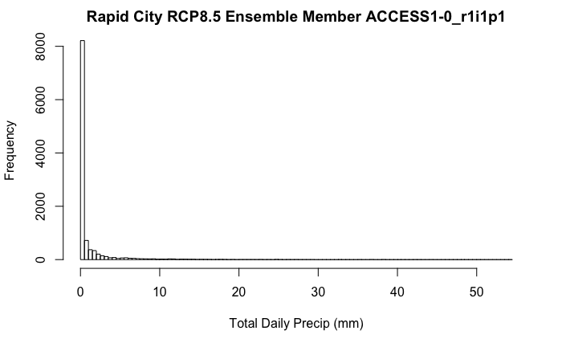

```r
ens_target = ensembles_to_use[1] # just use the first ensemble member
rpc_target = "RCP45"
subset = subset(variable,
                (Scenario==rpc_target)  &
                (Ensemble==ens_target)  &
                ((year>=base_start) &
                 (year<=base_end)   )
                )
# always nice to see what your data looks like.
hist(x      = subset$Variable, # omitting zero temperatures days
     xlab   = paste(variable_name,                   # xaxis title
                    " (",
                    variable_units,
                    ")",
                    sep=""),
     main   = paste(location_name,
                    paste("RCP8.5 Ensemble Member",ens_target),
                    sep = " "),
     freq   = TRUE,
     breaks = 100
     )
```

Now we run the fit command.

We will need a minimum threshold or the method fails.

Chose a reasonable value, here we chose 2mm (0.08“)

For reference, a wetting rain event is 0.1" or 2.54 mm

We are also using the Generalized Pareto method.

```r
fit_GP  = fevd(x          = Variable,
               data       = subset,
               verbose    = TRUE,
               threshold  = threshold_value,
               units      = variable_units,
               time.units = "365/year",
               type       = "GP",
               span       = period_span
               )
```

```
 Data span  0.08219178 years
Setting up parameter model design matrices.
Parameter model design matrices set up.
Using Lmoments estimates as initial estimates.  Initial value = 3479.568
Initial estimates are:
    scale     shape
3.9266053 0.2542597
Beginning estimation procedure.
Time difference of 0.04110789 secs
```

And we plot the results. You would prefer for the lines to rest on the “1:1” through a reasonable period. For a 30 year span, I’ll consider 15 return yers to be acceptable.

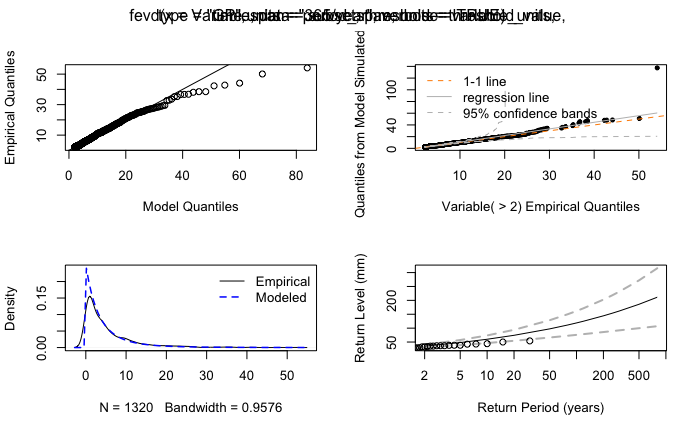

```r
plot(fit_GP)
```

We can also extract specific return events.

```r
return_intervals = seq(from =             2,
                       to   = period_span/2,
                       by   =             1)
n_return_intervals = length(return_intervals)
return_GP = return.level(x             = fit_GP,
                         return.period = return_intervals,
                         do.ci         = TRUE)
print(return_GP)
```

```
fevd(x = Variable, data = subset, threshold = threshold_value,
    type = "GP", span = period_span, units = variable_units,
    time.units = "365/year", verbose = TRUE)

[1] "Normal Approx."

                     95% lower CI Estimate 95% upper CI
2-year return level      30.14403 35.24617     40.34830
3-year return level      33.89638 40.56405     47.23171
4-year return level      36.69425 44.68453     52.67480
5-year return level      38.94338 48.09521     57.24704
6-year return level      40.83282 51.02952     61.22623
7-year return level      42.46689 53.61903     64.77117
8-year return level      43.90961 55.94585     67.98209
9-year return level      45.20321 58.06500     70.92679
10-year return level     46.37711 60.01529     73.65346
11-year return level     47.45265 61.82520     76.19775
12-year return level     48.44584 63.51634     78.58685
13-year return level     49.36900 65.10550     80.84200
14-year return level     50.23183 66.60600     82.98016
15-year return level     51.04212 68.02863     85.01513
```

```r
# tidy up the demo
remove(return_GP,
       fit_GP,
       subset)
```

To implement. Let’s create the storage arrays We will copy this over and over.

```r
# for each case/period create arrays for the return and CI bounds
# first for our base period
rcp45_base_period_return  = array(data= 0,
                                  dim = c(n_ensembles,
                                          n_return_intervals))
dimnames(rcp45_base_period_return) = list(ensembles_to_use,
                                         return_intervals)
rcp45_base_period_ci_ub   = rcp45_base_period_return
rcp45_base_period_ci_lb   = rcp45_base_period_return
rcp85_base_period_return  = rcp45_base_period_return
rcp85_base_period_ci_ub   = rcp45_base_period_return
rcp85_base_period_ci_lb   = rcp45_base_period_return
# then for our test period(s)
rcp45_per1_period_return  = rcp45_base_period_return
rcp45_per1_period_ci_ub   = rcp45_base_period_return
rcp45_per1_period_ci_lb   = rcp45_base_period_return
rcp85_per1_period_return  = rcp45_base_period_return
rcp85_per1_period_ci_ub   = rcp45_base_period_return
rcp85_per1_period_ci_lb   = rcp45_base_period_return
```

create a loop that goes between the ensembles.

```r
ens_target_num = 0
for (ens_target in ensembles_to_use) {
  ens_target_num = ens_target_num + 1

  ######################################
  #
  # Base Period
  #

  # create segments for RCP 45 and RCP 85 for your period(s)


  ens_target

  rpc_target = "RCP45"
  subset = subset(variable,
                  (Ensemble==ens_target)  &
                  (Scenario==rpc_target)  &
                  ((year>=base_start) &
                     (year<=base_end)   )
                       )

  # fit an extreme value dist to the data

  fit_GP_45 = fevd(x          = Variable,
                   data       = subset,
                   verbose    = FALSE,
                   threshold  = threshold_value,
                   units      = variable_units,
                   time.units = "365/year",
                   type       = "GP",
                   span       = period_span
                   )


  rpc_target = "RCP85"
  subset = subset(variable,
                  (Ensemble==ens_target)  &
                  (Scenario==rpc_target)  &
                  ((year>=base_start) &
                     (year<=base_end)   )
                       )


  fit_GP_85 = fevd(x          = Variable,
                   data       = subset,
                    verbose    = FALSE,
                   threshold  = threshold_value,
                   units      = variable_units,
                   time.units = "365/year",
                   type       = "GP",
                   span       = period_span
                   )

  # calculate the return periods and load into the temporary storage arrays.

  return_GP = return.level(x             = fit_GP_45,
                           return.period = return_intervals,
                           do.ci         = TRUE)

  rcp45_base_period_ci_lb[ ens_target_num, ] = return_GP[ , 1]
  rcp45_base_period_return[ens_target_num, ] = return_GP[ , 2]
  rcp45_base_period_ci_ub[ ens_target_num, ] = return_GP[ , 3]

  return_GP = return.level(x             = fit_GP_85,
                           return.period = return_intervals,
                           do.ci         = TRUE)

  rcp85_base_period_ci_lb[ ens_target_num, ] = return_GP[ , 1]
  rcp85_base_period_return[ens_target_num, ] = return_GP[ , 2]
  rcp85_base_period_ci_ub[ ens_target_num, ] = return_GP[ , 3]

  # tidy up

  remove(subset,
         fit_GP_45,
         fit_GP_85,
         return_GP)
  #
  ######################################


  ######################################
  #
  #  Period #1
  #

  # create segments for RCP 45 and RCP 85 for your period(s)


  rpc_target = "RCP45"
  subset = subset(variable,
                  (Ensemble==ens_target)  &
                  (Scenario==rpc_target)  &
                  ((year>=per1_start) &
                     (year<=per1_end)   )
                       )

  # fit an extreme value dist to the data

  fit_GP_45 = fevd(x          = Variable,
                   data       = subset,
                   verbose    = FALSE,
                   threshold  = threshold_value,
                   units      = variable_units,
                   time.units = "365/year",
                   type       = "GP",
                   span       = period_span
                   )

  rpc_target = "RCP85"
  subset = subset(variable,
                  (Ensemble==ens_target)  &
                  (Scenario==rpc_target)  &
                   ((year>=per1_start) &
                     (year<=per1_end)   )
                       )

  fit_GP_85 = fevd(x          = Variable,
                   data       = subset,
                   verbose    = FALSE,
                   threshold  = threshold_value,
                   units      = variable_units,
                   time.units = "365/year",
                   type       = "GP",
                   span       = period_span
                   )

  # calculate the return periods and load into the temporary storage arrays.

  return_GP = return.level(x             = fit_GP_45,
                           return.period = return_intervals,
                           do.ci         = TRUE)

  rcp45_per1_period_ci_lb[ ens_target_num, ] = return_GP[ , 1]
  rcp45_per1_period_return[ens_target_num, ] = return_GP[ , 2]
  rcp45_per1_period_ci_ub[ ens_target_num, ] = return_GP[ , 3]

  return_GP = return.level(x             = fit_GP_85,
                           return.period = return_intervals,
                           do.ci         = TRUE)

  rcp85_per1_period_ci_lb[ ens_target_num, ] = return_GP[ , 1]
  rcp85_per1_period_return[ens_target_num, ] = return_GP[ , 2]
  rcp85_per1_period_ci_ub[ ens_target_num, ] = return_GP[ , 3]

  # tidy up

  remove(subset,
         fit_GP_45,
         fit_GP_85,
         return_GP)
  #
  ######################################
}
```

Convert output into neat and tidy data frames

```r
################################################
#
# let's start with the base period
#
# melt 2-d arrays into frames.
rcp45_base   = melt(data       = rcp45_base_period_return,
                    varnames   = c("Ensembles","return_intervals"),
                    na.rm      = TRUE,
                    value.name = "RCP45_Return_Period")
rcp45_cib_lb = melt(data       = rcp45_base_period_ci_lb,
                    varnames   = c("Ensembles","return_intervals"),
                    na.rm      = TRUE,
                    value.name = "RCP45_Lower_95_CI")
rcp45_cib_ub = melt(data       = rcp45_base_period_ci_ub,
                    varnames   = c("Ensembles","return_intervals"),
                    na.rm      = TRUE,
                    value.name = "RCP45_Upper_95_CI")
rcp85_base   = melt(data       = rcp85_base_period_return,
                    varnames   = c("Ensembles","return_intervals"),
                    na.rm      = TRUE,
                    value.name = "RCP85_Return_Period")
rcp85_cib_lb = melt(data       = rcp85_base_period_ci_lb,
                    varnames   = c("Ensembles","return_intervals"),
                    na.rm      = TRUE,
                    value.name = "RCP85_Lower_95_CI")
rcp85_cib_ub = melt(data       = rcp85_base_period_ci_ub,
                    varnames   = c("Ensembles","return_intervals"),
                    na.rm      = TRUE,
                    value.name = "RCP85_Upper_95_CI")
# combine the fields into a single data frame for each one.
rcp45_base$RCP45_Lower_95_CI = rcp45_cib_lb$RCP45_Lower_95_CI
rcp45_base$RCP45_Upper_95_CI = rcp45_cib_ub$RCP45_Upper_95_CI
rcp85_base$RCP85_Lower_95_CI = rcp85_cib_lb$RCP85_Lower_95_CI
rcp85_base$RCP85_Upper_95_CI = rcp85_cib_ub$RCP85_Upper_95_CI
# tidy up
remove(rcp85_base_period_ci_lb,
       rcp85_base_period_return,
       rcp85_base_period_ci_ub,
       rcp85_cib_lb,
       rcp85_cib_ub)
remove(rcp45_base_period_ci_lb,
       rcp45_base_period_return,
       rcp45_base_period_ci_ub,
       rcp45_cib_lb,
       rcp45_cib_ub)
#
################################################
################################################
#
# and we can continue with the test period
#
rcp45_per1   = melt(data       = rcp45_per1_period_return,
                    varnames   = c("Ensembles","return_intervals"),
                    na.rm      = TRUE,
                    value.name = "RCP45_Return_Period")
rcp45_ci1_lb = melt(data       = rcp45_per1_period_ci_lb,
                    varnames   = c("Ensembles","return_intervals"),
                    na.rm      = TRUE,
                    value.name = "RCP45_Lower_95_CI")
rcp45_ci1_ub = melt(data       = rcp45_per1_period_ci_ub,
                    varnames   = c("Ensembles","return_intervals"),
                    na.rm      = TRUE,
                    value.name = "RCP45_Upper_95_CI")
rcp85_per1   = melt(data       = rcp85_per1_period_return,
                    varnames   = c("Ensembles","return_intervals"),
                    na.rm      = TRUE,
                    value.name = "RCP85_Return_Period")
rcp85_ci1_lb = melt(data       = rcp85_per1_period_ci_lb,
                    varnames   = c("Ensembles","return_intervals"),
                    na.rm      = TRUE,
                    value.name = "RCP85_Lower_95_CI")
rcp85_ci1_ub = melt(data       = rcp85_per1_period_ci_ub,
                    varnames   = c("Ensembles","return_intervals"),
                    na.rm      = TRUE,
                    value.name = "RCP85_Upper_95_CI")
# combine the fields into a single data frame for each one.
rcp45_per1$RCP45_Lower_95_CI = rcp45_ci1_lb$RCP45_Lower_95_CI
rcp45_per1$RCP45_Upper_95_CI = rcp45_ci1_ub$RCP45_Upper_95_CI
rcp85_per1$RCP85_Lower_95_CI = rcp85_ci1_lb$RCP85_Lower_95_CI
rcp85_per1$RCP85_Upper_95_CI = rcp85_ci1_ub$RCP85_Upper_95_CI
# tidy up
remove(rcp85_per1_period_ci_lb,
       rcp85_per1_period_return,
       rcp85_per1_period_ci_ub,
       rcp85_ci1_lb,
       rcp85_ci1_ub)
remove(rcp45_per1_period_ci_lb,
       rcp45_per1_period_return,
       rcp45_per1_period_ci_ub,
       rcp45_ci1_lb,
       rcp45_ci1_ub)
#
################################################
```

Plot return output

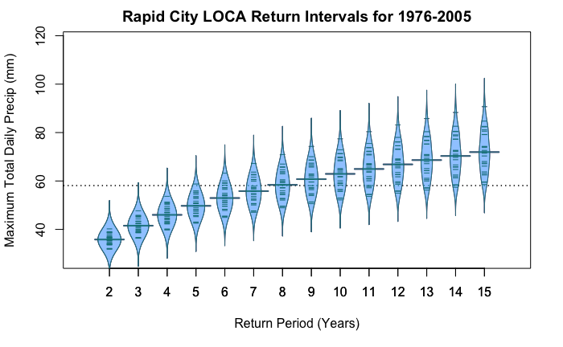

```r
# I am making my own colours
darkcyan = rgb(red   = 0.00,
               green = 0.50,
               blue  = 0.50,
               alpha = 0.75)  # 1 = opaque; 0 = fully clear
cyan     = rgb(red   = 0.00,
               green = 1.00,
               blue  = 1.00,
               alpha = 0.50)
darkblue = rgb(red   = 0.00,
               green = 0.00,
               blue  = 0.50,
               alpha = 0.75)
blue     = rgb(red   = 0.00,
               green = 0.00,
               blue  = 1.00,
               alpha = 0.50)
darkmag  = rgb(red   = 0.50,
               green = 0.00,
               blue  = 0.50,
               alpha = 0.75)
magenta  = rgb(red   = 1.00,
               green = 0.00,
               blue  = 1.00,
               alpha = 0.50)
darkred  = rgb(red   = 0.50,
               green = 0.00,
               blue  = 0.00,
               alpha = 0.75)
red      = rgb(red   = 1.00,
               green = 0.00,
               blue  = 0.00,
               alpha = 0.50)
beanplot(formula     = RCP85_Return_Period~return_intervals,  # formula selection for y axis
         data        = rcp85_base,                            # data frame to use
         col         = c(magenta,  # area fill                # Color Scheme
                         darkmag,  # lines
                         darkmag,  # outside of bean line
                         darkmag), # mean line
         border      = darkmag,                               # border color
         overallline = "median",                              # can't get rid of this dang thing
         beanlines   = "median",                              # use median for the "central value"
         main        = paste(location_name,
                             " LOCA Return Intervals for ",         # title caption
                             base_start,
                            "-",
                            base_end,
                            sep=""),
         xlab        = "Return Period (Years)",               # xaxis title
         ylab        = paste("Maximum ",
                             variable_name,                   # yaxis title
                             " (",
                             variable_units,
                             ")",
                             sep=""),
         log         = "",                                    # overide log axis on y (it defaults to log for big datasets)
         xlim        = c(0,period_span/2),                    # x axis range
         ylim        = c(min(rcp45_base$RCP45_Lower_95_CI,    # y axis range
                             rcp85_base$RCP85_Lower_95_CI,
                             rcp45_per1$RCP45_Lower_95_CI,
                             rcp85_per1$RCP45_Lower_95_CI),
                         max(rcp45_base$RCP45_Upper_95_CI,    # y axis range
                             rcp85_base$RCP85_Upper_95_CI,
                             rcp45_per1$RCP45_Upper_95_CI,
                             rcp85_per1$RCP45_Upper_95_CI)
                        )
        )


beanplot(formula    = RCP45_Return_Period~return_intervals,
         data        = rcp45_base,
         add         = TRUE,
         beanlines   = "median",
         overallline = "median",
         col         = c(cyan,      # area fill
                         darkcyan,  # lines
                         darkcyan,  # outside of bean line
                         darkcyan), # mean line
         border      = darkcyan
        )
```

Trying something new. Now we can do this a “split” plot.

and for the future period.;;

```r
# create a temporary array to hold just the return periods for simplicity
deleteme     = data.frame(Ensembles        = rcp45_base$Ensembles,
                          return_intervals = rcp45_base$return_intervals,
                          RCP45            = rcp45_per1$RCP45_Return_Period,
                          RCP85            = rcp85_per1$RCP85_Return_Period)
# melt the RCP45 and RCP85 columns into a new field.
base_all     = melt(data       = deleteme,
                    varnames   = c("Ensembles","return_intervals","Scenario"),
                    id.vars    = c("Ensembles","return_intervals"),
                    na.rm      = TRUE,
                    value.name = "Return_Period_Values")
colnames(base_all) <- c("Ensembles","return_intervals","Scenario","Return_Period_Values")
# for this to work below, the program will need to search through ONE variable for the axis
# you can use two (or more) sub-categories.
#
# to do this you need to create a new variable in the data table that will have two
# parts, separated by a space character.
#
# this your x-axis + "series" category would be
#
#  001 Cat1
#  002 Cat1
#  003 Cat1
#  001 Cat2
#  002 Cat3
# ... and so on.
#
# in this case we will have our return period year and then the RCP scenario.
# (We could also do this for different periods for a single RCP scenario)
#
# thus...
#  02 RCP45 (we need that leading zero)
#  02 RCP85
#   ...
#  20 RCP45
#  20 RCP85
base_all$merged_period_scenarios = paste(sprintf("%2d", base_all$return_intervals),
                                         base_all$Scenario,
                                         sep = " ")
# tidy up!
remove(deleteme)
```

And now we can plot this one. This will create a “split” bean plot which is about as complex and messy as I want to get right now.

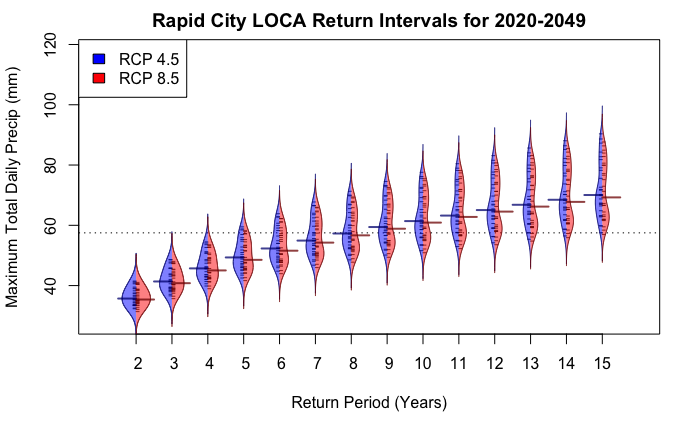

```r
beanplot(formula     = Return_Period_Values~merged_period_scenarios,  # formula selection for y axis
         data        = base_all,                                     # data frame to use
         col         = list(c(blue, darkblue,darkblue,darkblue),  # same order as earlier for each series
                            c(red,  darkred,  darkred, darkred)),
         border      = c(darkblue,darkred),
         overallline = "median",                              # can't get rid of this dang thing
         beanlines   = "median",                              # use median for the "central value"
         side        = "both",
         main        = paste(location_name,
                             " LOCA Return Intervals for ",         # title caption
                             per1_start,
                             "-",
                             per1_end,
                             sep=""),
         xlab        = "Return Period (Years)",               # xaxis title
         ylab        = paste("Maximum ",
                             variable_name,                   # yaxis title
                             " (",
                             variable_units,
                             ")",
                             sep=""),
         log         = "",                                    # overide log axis on y (it defaults to log for big datasets)
         xlim        = c(0,period_span/2),                    # x axis range
         ylim        = c(min(rcp45_base$RCP45_Lower_95_CI,    # y axis range
                             rcp85_base$RCP85_Lower_95_CI,
                             rcp45_per1$RCP45_Lower_95_CI,
                             rcp85_per1$RCP45_Lower_95_CI),
                         max(rcp45_base$RCP45_Upper_95_CI,    # y axis range
                             rcp85_base$RCP85_Upper_95_CI,
                             rcp45_per1$RCP45_Upper_95_CI,
                             rcp85_per1$RCP45_Upper_95_CI)
                        )
        )
legend("topleft",
       fill   = c("blue", "red"),
       legend = c("RCP 4.5", "RCP 8.5"))
```